# Summary Report of DecisionTree on bank_client_data

Team B : Achal, Gupta —————A00258772

April 5, 2019

# Data Set Information:

The dataset is about direct marketing campaigns of a Portuguese banking institution. The method of data being collected in this marketing campaigns were based on phone calls. Often, more than one contact to the same client was required, in order to access if the product (bank term deposit) would be subscribed.

# Attribute Information

### Input variables: bank client data:

1 - **age:** (numeric)  
2 - **job:** type of job (categorical: ‘admin.’,‘blue-collar’,‘entrepreneur’,‘housemaid’,‘management’,‘retired’,‘self-employed’,‘services’,‘student’,‘technician’,‘unemployed’,‘unknown’)  
3 - **marital:** marital status (categorical: ‘divorced’,‘married’,‘single’,‘unknown’; note: ‘divorced’ means divorced or widowed)  
4 - **education:** (categorical: ‘basic.4y’,‘basic.6y’,‘basic.9y’,‘high.school’,‘illiterate’,‘professional.course’,‘university.degree’,‘unknown’)  
5 - **default:** has credit in default? (categorical: ‘no’,‘yes’,‘unknown’)  
6 - **housing:** has housing loan? (categorical: ‘no’,‘yes’,‘unknown’)  
7 - **loan:** has personal loan? (categorical: ‘no’,‘yes’,‘unknown’)

### related with the last contact of the current campaign:

8 - **contact:** contact communication type (categorical: ‘cellular’,‘telephone’)  
9 - **month:** last contact month of year (categorical: ‘jan’, ‘feb’, ‘mar’, …, ‘nov’, ‘dec’)  
10 - **day_of_week:** last contact day of the week (categorical: ‘mon’,‘tue’,‘wed’,‘thu’,‘fri’)  
11 - **duration:** last contact duration, in seconds (numeric). Important note: this attribute highly affects the output target (e.g., if duration=0 then y=‘no’). Yet, the duration is not known before a call is performed. Also, after the end of the call y is obviously known. Thus, this input should only be included for benchmark purposes and should be discarded if the intention is to have a realistic predictive model.

### other attributes:

12 - **campaign:** number of contacts performed during this campaign and for this client (numeric, includes last contact)  
13 - **pdays:** number of days that passed by after the client was last contacted from a previous campaign (numeric; 999 means client was not previously contacted)  
14 - **previous:** number of contacts performed before this campaign and for this client (numeric)  
15 - **poutcome:** outcome of the previous marketing campaign (categorical: ‘failure’,‘nonexistent’,‘success’)

### social and economic context attributes:

16 - **emp.var.rate:** employment variation rate - quarterly indicator (numeric)  
17 - **cons.price.idx:** consumer price index - monthly indicator (numeric)  
18 - **cons.conf.idx:** consumer confidence index - monthly indicator (numeric)  
19 - **euribor3m:** euribor 3 month rate - daily indicator (numeric)  
20 - **nr.employed:** number of employees - quarterly indicator (numeric)

### Output variable (desired target):

21 - **y** - has the client subscribed a term deposit? (binary: ‘yes’,‘no’)

## Correlation Matrix

Positive correlations are displayed in blue and negative correlations in red color.  
Color intensity is proportional to the correlation coefficients.  
It is very useful to highlight the most correlated variables in a data table.  
In this plot, correlation coefficients is colored according to the value.

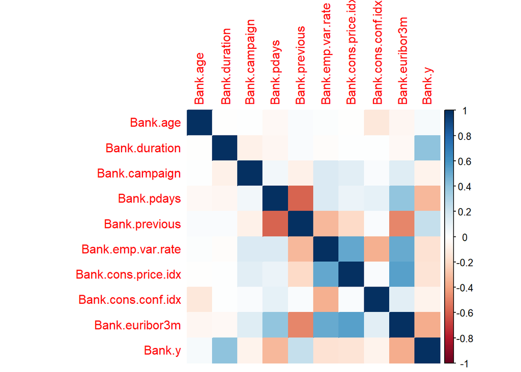

## Age Distribution

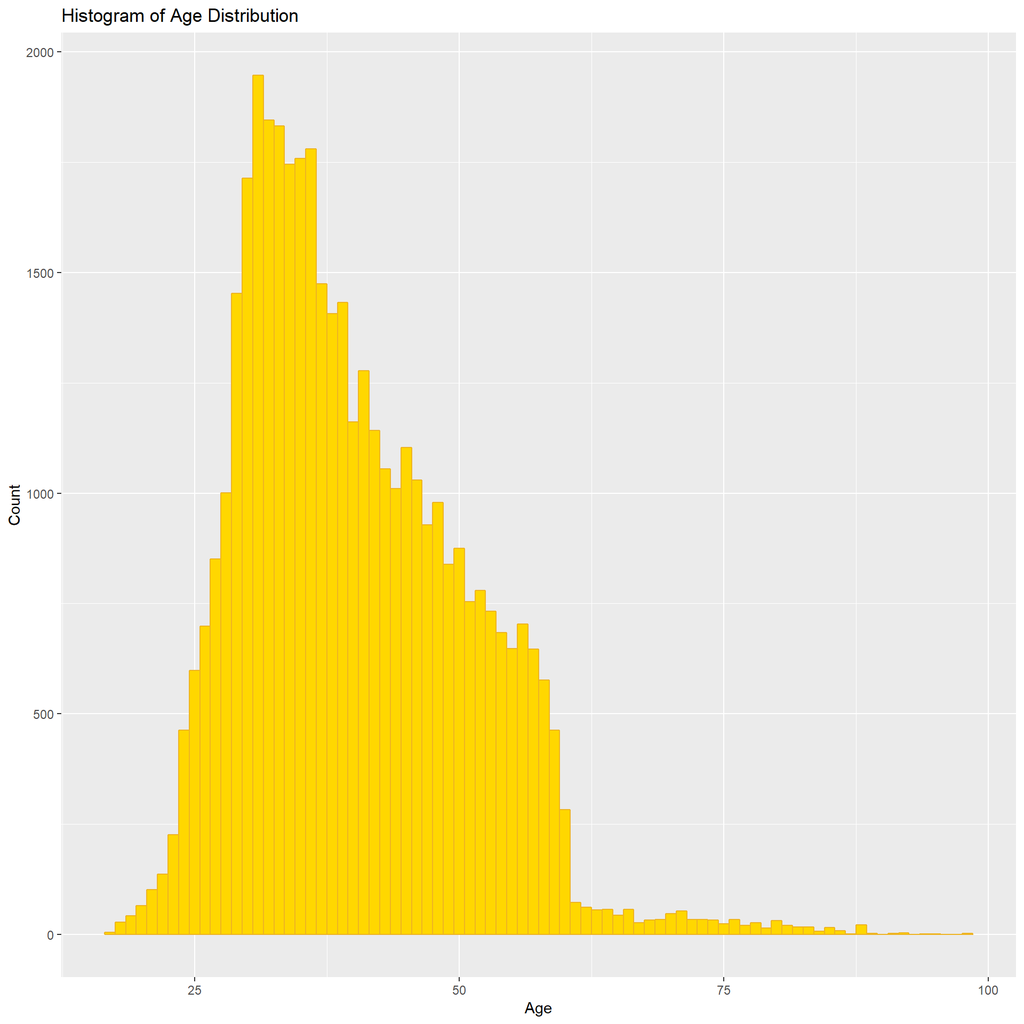

Figure above shows that, **Age** is not normally distributed and it lends on the left side and it doesn’t show that **Age** have a high effect to the variable **y**. People from all the **Age** category could have subscribed for the term deposit.

## No. of Clients working in Different Department

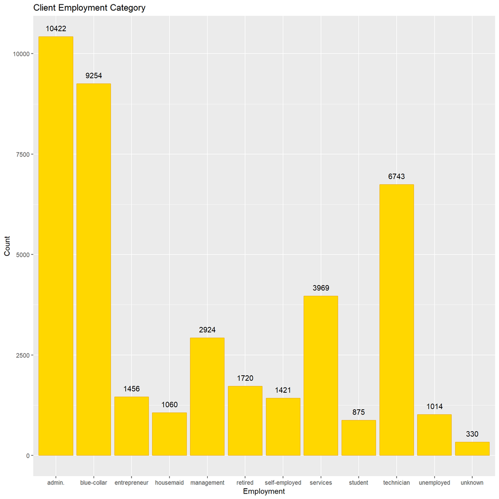

Figure above shows that, most of the clients are admin, blue collar job, and technician respectively.

## Marital status of clients

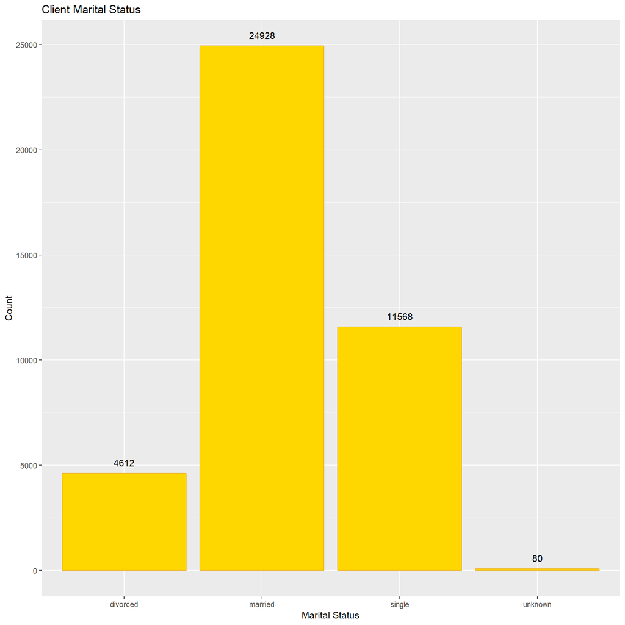

Figure above shows that, most of our client are married. Having the possibility of family members to look after.

## Education Distribution of clients

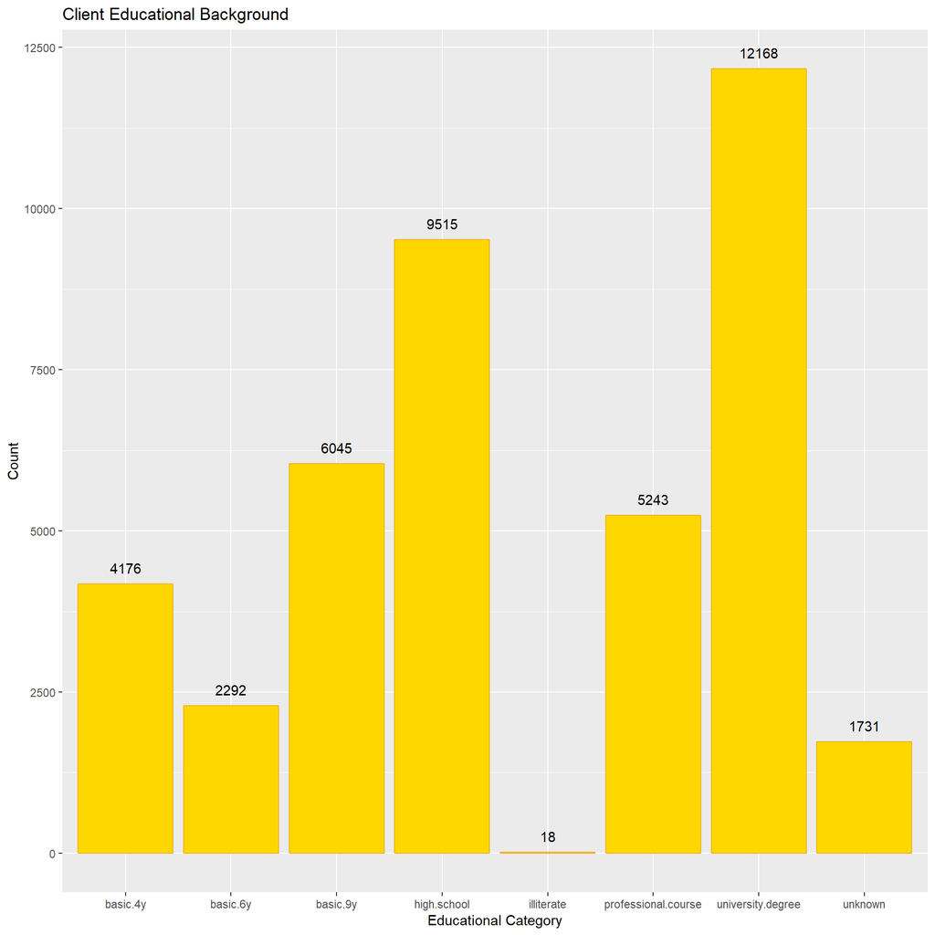

Figure above shows that, most of the clients having a university degree. Hence, the literacy rate is high amoung the clients.

## Ways to Contact Client

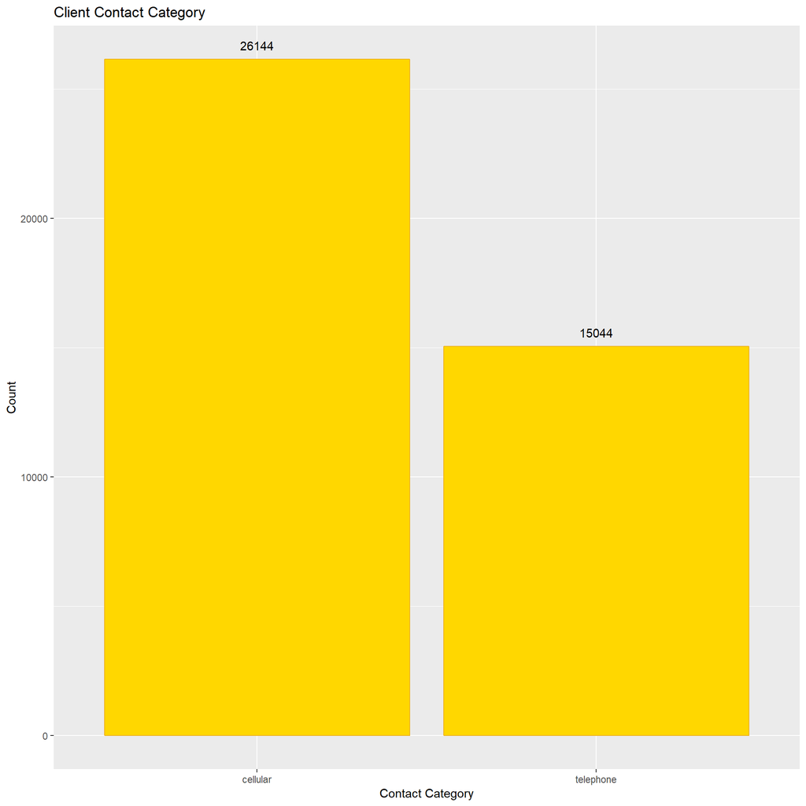

Figure above shows that, there are two ways to contact clients and cellular mode of contact are most preferred.

## Months Count

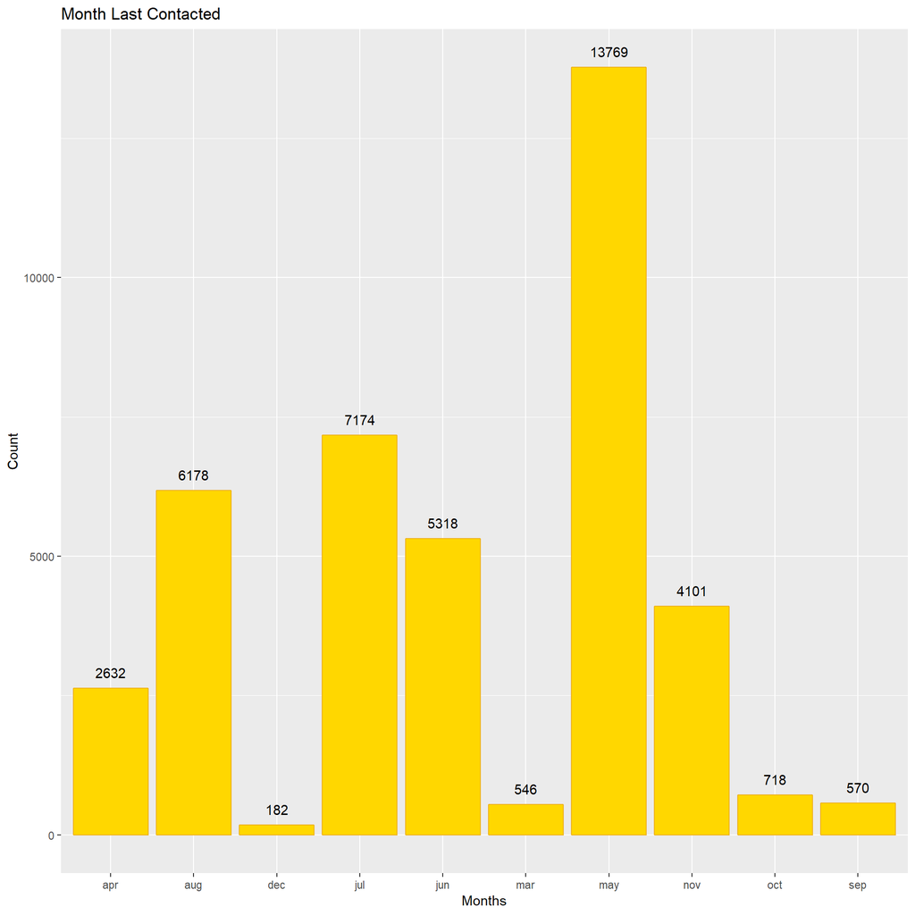

Figure above shows that, top 3 months of most number of client contacted are May, July, and August respectively.

## Education level Vs Getting loans

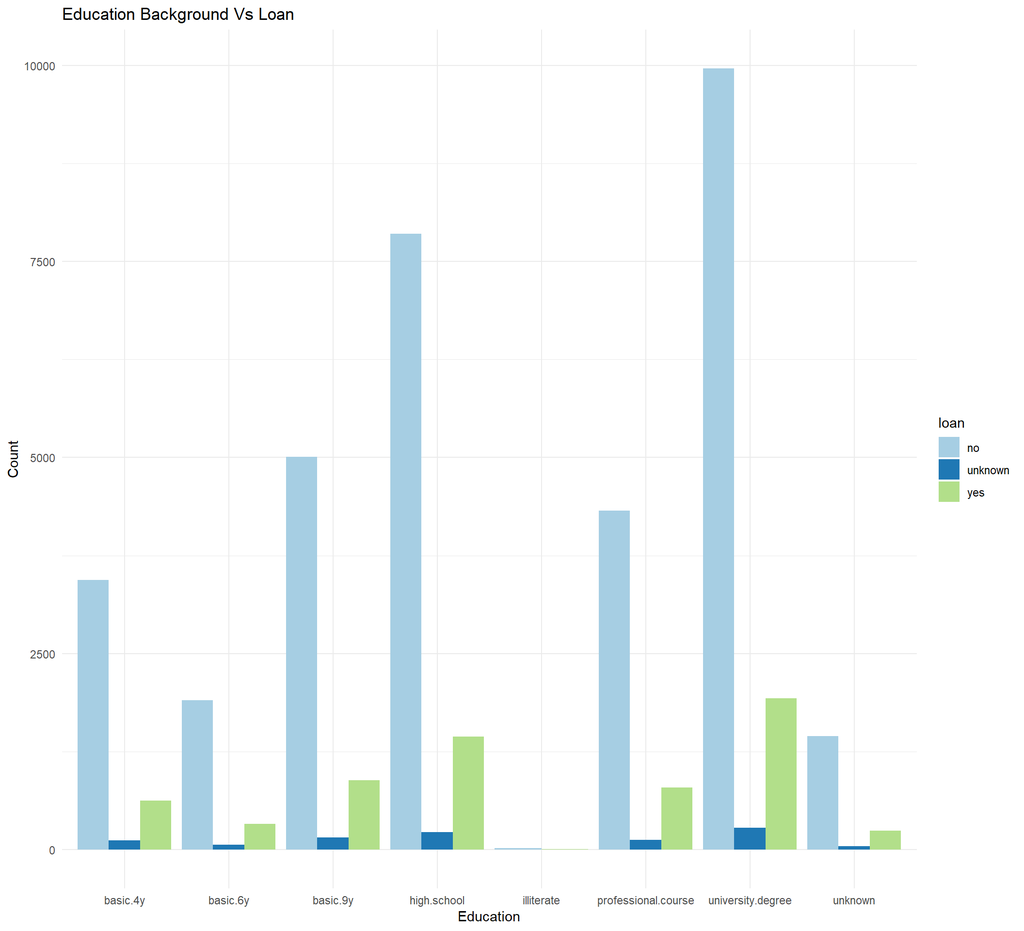

## Impact of previous campain on term deposit

[figure not shown]

Figure above shows, how the previous campain affects on the term deposit.  
It shows thats the last campain was not that successfull and the failure ration is really high.

# Decision tree

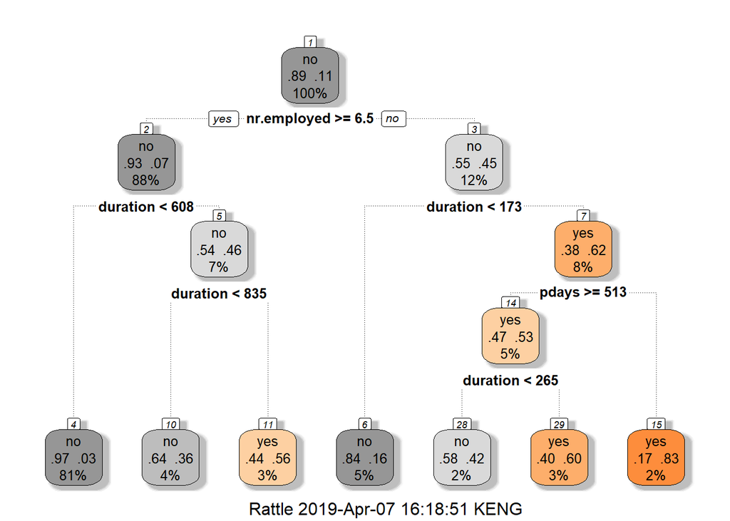

# Confusion matrix Report

```
## Confusion Matrix and Statistics
##
##
## Bank_prediction    no   yes
##             no  10453   726
##             yes   378   682
##
##                Accuracy : 0.9098
##                  95% CI : (0.9046, 0.9148)
##     No Information Rate : 0.885
##     P-Value [Acc > NIR] : < 2.2e-16
##
##                   Kappa : 0.5036
##
##  Mcnemar's Test P-Value : < 2.2e-16
##
##             Sensitivity : 0.9651
##             Specificity : 0.4844
##          Pos Pred Value : 0.9351
##          Neg Pred Value : 0.6434
##              Prevalence : 0.8850
##          Detection Rate : 0.8541
##    Detection Prevalence : 0.9134
##       Balanced Accuracy : 0.7247
##
##        'Positive' Class : no
##
```

# so our model is more than 90% accurate.

From the matrix, it shows that there are **two possible predicted classes**: “yes” and “no”. Predicting whether the client subscribed a term deposit or not, “yes” would mean they have subscribed, and “no” would mean they don’t.

**Accuracy:** It will tell how accurate your model is.  
**Sensitivity:** It is also know as True positive rate.  
**Specificity:** It is also know as True Negative rate.  
**Positive Predictive Value (PPV):** when the prediction is positive, how often is it correct.  
**Negative Predictive Value (NPV):** when the prediction is negative, how often is it correct.